# HW3_Anderson

Author

Mitchell Anderson

```r
setwd("~/Desktop/usc.health.dat.sci/PM566_Labs/PM566Labs")
read.csv("pubmed.csv")
```

[output not shown]

[output cut: 6469 more lines]

```r
pubmed_data<-read.csv("pubmed.csv")
library(tidytext)
library(tidyverse)
library(dplyr)
library(ggplot2)
library(stringr)
```

EDA

```r
glimpse(pubmed_data)
```

```
Rows: 3,241
Columns: 2
$ abstract <chr> "Background and aims: Many patients with coronavirus disease …
$ term     <chr> "covid", "covid", "covid", "covid", "covid", "covid", "covid"…
```

```r
dim(pubmed_data)
```

```
[1] 3241    2
```

```r
head(pubmed_data)
```

```
                                                                                                                                                                                                                                                                                                            …
1                                                                                                                                                                                                                                                                                                           …
2                                                                                                                                                                                                                                                                                                           …
3                                                                                                                                                                                                                                                                                                           …
4 OBJECTIVE. The objective of our study was to determine the misdiagnosis rate of radiologists for coronavirus disease 2019 (COVID-19) and evaluate the performance of chest CT in the diagnosis and management of COVID-19. The CT features of COVID-19 are reported and compared with the CT features of o…
5                                                                                                                                                                                                                                                                                                           …
6                                                                                                                                                                                                                                                                                                           …
   term
1 covid
2 covid
3 covid
4 covid
5 covid
6 covid
```

```r
tail(pubmed_data)
```

```
                                                                                                                                                                                                                                                                                                            …
3236                                                                                                                                                                                                                                       From Antenatal Diagnostic Center referrals over 22 months, consul…
3237 Objective: To describe the duration of expectant management and the indications for termination of expectant management of pregnancies complicated by severe pre-eclampsia remote from term. Study design: We identified pregnancies complicated by severe pre-eclampsia diagnosed between 24 weeks and…
3238                                                                                                                                                                                                                                                         Objective: To examine the effect of a combinati…
3239                                                                                                                                                                                                                                                                     Objective: To assess obstetric outc…
3240                                                                                                                                                                                                                                                                                                        …
3241                                                                                                                                                                                                                                                                                                        …
             term
3236 preeclampsia
3237 preeclampsia
3238 preeclampsia
3239 preeclampsia
3240 preeclampsia
3241 preeclampsia
```

```r
str(pubmed_data)
```

```
'data.frame':   3241 obs. of  2 variables:
 $ abstract: chr  "Background and aims: Many patients with coronavirus disease 2019 (COVID-19) have underlying cardiovascular (CV)"| __truncated__ "Introduction: Contradictory data have been reported on the incidence of stroke in patients with COVID-19 and th"| __truncated__ "This article aims at co…
 $ term    : chr  "covid" "covid" "covid" "covid" ...
```

The dataset we are using, “pubmed_data” is a data frame structure with 3,241 observations/rows and 2 character class variables/columns. The columns are titled “abstract” and “term”. The abstract term contains a unique abstract to a pubmed article for a given search term. The term column contains the specific term that yielded the given abstract in that particular row.

1. (15 points) How many abstracts are associated with each search term? Tokenize the abstracts and count the number of each token. Do you see anything interesting? What are the 5 most common tokens for each search term?

```r
# Count how many abstracts are associated with each search term
pubmed_data %>%
  count(term,name="abstract_quantity") %>%
  arrange(desc(abstract_quantity))
```

```
             term abstract_quantity
1           covid               981
2 prostate cancer               787
3    preeclampsia               780
4 cystic fibrosis               376
5      meningitis               317
```

```r
# Tokenize abstracts and find top 5 most common tokens per search term
pubmed_tokens<-pubmed_data %>%
  #adds the new column "abstract_quantity"
  add_count(term,name="abstract_quantity") %>%
  #breaks text from abstract column into tokens
  unnest_tokens(output="tokens",input=abstract) %>%
  #convert tokens all to a uniform case size, filter out non-alphabetic characters
  mutate(tokens =str_to_lower(tokens)) %>%
  filter(str_detect(tokens,"^[a-z]+$")) %>%
  group_by(term, tokens,abstract_quantity) %>%
  summarize(token_count =n(),.groups="drop") %>%
  group_by(term) %>%
  #sort by term and token count
  arrange(term,desc(token_count),tokens) %>%
  mutate(rank_in_term=row_number()) %>%
  filter(rank_in_term<=5) %>%
  ungroup() %>%
  arrange(term,rank_in_term)

# Display the result
print(pubmed_tokens)
```

```
# A tibble: 25 × 5
   term            tokens abstract_quantity token_count rank_in_term
   <chr>           <chr>              <int>       <int>        <int>
 1 covid           the                  981        9741            1
 2 covid           of                   981        7668            2
 3 covid           covid                981        7275            3
 4 covid           and                  981        6861            4
 5 covid           in                   981        4526            5
 6 cystic fibrosis the                  376        2677            1
 7 cystic fibrosis of                   376        2304            2
 8 cystic fibrosis and                  376        1777            3
 9 cystic fibrosis in                   376        1497            4
10 cystic fibrosis to                   376        1011            5
# ℹ 15 more rows
```

The five terms in the column titled “term” to look for are “covid”, “meningitis”, “prostate cancer”, “cystic fibrosis”, and “preeclampsia”. The count reveals that there are 981 counts for “covid”, 787 counts for “prostate cancer”, 780 counts for “preeclampsia”, 376 counts for “cystic fibrosis”, and 317 counts for “meningitis”. The object “pubmed_tokens” reveals the top five tokens for each term. Since no stop words were filtered out, the top five tokens for each search term do not provide much insight or useful information. For example the term “covid” yielded the top five tokens as “the”, “of”, “covid”, “and”, and “in”. The other search terms also yielded very similar tokens (as seen in the printout of “pubmed_tokens”).

2. (15 points) Does removing stop words change what tokens appear as the most frequent? What are the 5 most common tokens for each search term after removing stop words?

```r
pubmed_tokens_stop_filtered<-pubmed_data %>%
  #split into individual words
  unnest_tokens(output="tokens",input=abstract) %>%
  #convert to lowercase/keep only alphabetical tokens
  mutate(tokens=str_to_lower(tokens)) %>%
  filter(str_detect(tokens,"^[a-z]+$")) %>%
  #use get_stopwords() to filter out stop words as well as the specified words in search_tokens
  anti_join(get_stopwords(),by=c("tokens"="word")) %>%
   group_by(term,tokens) %>%
  summarize(token_count = n(),.groups="drop") %>%
  #arrange and categorize by term
  group_by(term) %>%
  arrange(term,desc(token_count),tokens) %>%
  mutate(rank_in_term=row_number()) %>%
  filter(rank_in_term<=5) %>%
  ungroup() %>%

  arrange(term,rank_in_term)

print(pubmed_tokens_stop_filtered)
```

```
# A tibble: 25 × 4
   term            tokens   token_count rank_in_term
   <chr>           <chr>          <int>        <int>
 1 covid           covid           7275            1
 2 covid           patients        2293            2
 3 covid           disease          943            3
 4 covid           pandemic         800            4
 5 covid           cases            659            5
 6 cystic fibrosis fibrosis         867            1
 7 cystic fibrosis cystic           862            2
 8 cystic fibrosis cf               625            3
 9 cystic fibrosis patients         586            4
10 cystic fibrosis disease          400            5
# ℹ 15 more rows
```

In this question I created the object “pubmed_tokens_stop_filtered”, which contains the top five tokens (in order by rank 1-5) and displays how often the given tokens occur, while filtering out stop words. The abstracts reveal key tokens that relate specifically to the search terms. The next code chunk filters out the search terms themselves, but for the remainder of the homework we will use “pubmed_tokens_stop_filtered”.

```r
#filter out the terms so they don't appear as tokens
search_tokens<-c("covid","cystic","fibrosis","cf","meningitis","meningeal","pre","eclampsia","preeclampsia","cancer","prostate","patients","disease","pandemic","coronavirus")

pubmed_tokens_terms_filtered<-pubmed_data %>%
  #split into individual words
  unnest_tokens(output="tokens",input=abstract) %>%
  #convert to lowercase/keep only alphabetical tokens
  mutate(tokens=str_to_lower(tokens)) %>%
  filter(str_detect(tokens,"^[a-z]+$")) %>%
  #use get_stopwords() to filter out stop words as well as the specified words in search_tokens
  anti_join(get_stopwords(),by=c("tokens"="word")) %>%
  filter(!tokens%in%search_tokens) %>%
   group_by(term,tokens) %>%
  summarize(token_count=n(),.groups="drop") %>%
  #arrange and categorize by term
  group_by(term) %>%
  arrange(term,desc(token_count),tokens) %>%
  mutate(rank_in_term=row_number()) %>%
  filter(rank_in_term<= 5) %>%
  ungroup() %>%

  arrange(term,rank_in_term)

print(pubmed_tokens_terms_filtered)
```

```
# A tibble: 25 × 4
   term            tokens    token_count rank_in_term
   <chr>           <chr>           <int>        <int>
 1 covid           cases             659            1
 2 covid           health            647            2
 3 covid           infection         556            3
 4 covid           results           532            4
 5 covid           study             532            5
 6 cystic fibrosis diagnosis         192            1
 7 cystic fibrosis clinical          189            2
 8 cystic fibrosis treatment         178            3
 9 cystic fibrosis lung              161            4
10 cystic fibrosis years             160            5
# ℹ 15 more rows
```

(Extra step I performed but not necessary) This version yields more specific results because the terms are filtered out. For example, the term “preeclampsia” used the tokens “women” and “pregnancy” most often. This is logical because preeclampsia is a condition specific to women that are pregnant. Additionally, the term “meningitis” held the most common token as “csf” (cerebrospinal fluid), which is where diagnistics are ran to assess for meningitis. I filtered out certain words that too closely resembled the search terms such as “covid”, “cystic”, “fibrosis”, “cf”, “meningitis”, “meningeal”, “pre”, “eclampsia”, “preeclampsia”, “cancer”, “prostate”, “patients”, “disease”, and “pandemic”. Filtering out stop words and terms that too closeley resemble the search term itself allow us to see tokens that are specific to the nature of the term at hand.

3. (10 points) Tokenize the abstracts into bigrams. Find the 10 most common bigrams and visualize them.

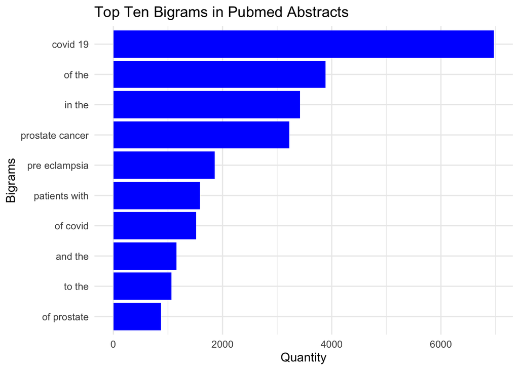

```r
#tokenize into bigrams
pubmed_bigrams_10<-pubmed_data %>%
  unnest_tokens(ngrams,abstract,token="ngrams",n=2) %>%
  count(ngrams,sort=TRUE) %>%
  slice_max(n,n=10)
#visualize top ten
ggplot(pubmed_bigrams_10,aes(x=reorder(ngrams,n),y=n))+
  geom_col(fill="blue")+
  coord_flip()+
  labs(title = "Top Ten Bigrams in Pubmed Abstracts",x="Bigrams",y="Quantity")+
  theme_minimal(base_size=12)
```

```r
print(pubmed_bigrams_10)
```

```
            ngrams    n
1         covid 19 6969
2           of the 3883
3           in the 3418
4  prostate cancer 3222
5    pre eclampsia 1854
6    patients with 1587
7         of covid 1519
8          and the 1154
9           to the 1061
10     of prostate  870
```

The object titled “pubmed_bigrams_10” contains the exact count of each bigram. The most common bigram was “covid 19” with a count of 6,969, followed by “of the” with a count of 3,883 and “in the” with a count of 3,418. Stop words were not filtered out in this instance.

4. (20 points) Calculate the TF-IDF value for each word-search term combination (here you want the search term to be the “document”). What are the 5 tokens from each search term with the highest TF-IDF value? How are the results different from the answers you got in Question 1?

```r
pubmed_tf_idf <- pubmed_data %>%
  unnest_tokens(output = "tokens", input = abstract) %>%
  mutate(tokens = str_to_lower(tokens)) %>%
  filter(str_detect(tokens, "^[a-z]+$")) %>%
  anti_join(get_stopwords(), by = c("tokens" = "word")) %>%
  count(term, tokens, sort = TRUE) %>%
  bind_tf_idf(tokens, term, n) %>%
  group_by(term) %>%
  arrange(term, desc(tf_idf)) %>%
  mutate(rank_in_term = row_number()) %>%
  filter(rank_in_term <= 5) %>%
  ungroup() %>%
  arrange(term, rank_in_term)

print(pubmed_tf_idf)
```

```
# A tibble: 25 × 7
   term            tokens          n      tf   idf  tf_idf rank_in_term
   <chr>           <chr>       <int>   <dbl> <dbl>   <dbl>        <int>
 1 covid           covid        7275 0.0637  1.61  0.102              1
 2 covid           pandemic      800 0.00700 1.61  0.0113             2
 3 covid           coronavirus   647 0.00566 1.61  0.00911            3
 4 covid           sars          372 0.00326 1.61  0.00524            4
 5 covid           cov           334 0.00292 1.61  0.00471            5
 6 cystic fibrosis cf            625 0.0211  0.916 0.0194             1
 7 cystic fibrosis fibrosis      867 0.0293  0.511 0.0150             2
 8 cystic fibrosis cystic        862 0.0292  0.511 0.0149             3
 9 cystic fibrosis cftr           86 0.00291 1.61  0.00468            4
10 cystic fibrosis sweat          83 0.00281 1.61  0.00452            5
# ℹ 15 more rows
```

TF-IDF is a function that measures the “importance” of a word in a series of texts. Term frequency (TF) is calculated by dividing the count of a specific word in a text by the total number of words in a text. Inverse document frequency (IDF) is calculated by taking the log of the total number of texts divided by the number of texts containing the specified word. TF-IDF is the product of TF and IDF. In this scenario, we used TF-IDF to measure the importance of the top five tokens for each term. These tokens differ from the tokens found in Question 1 for a couple reasons. First, the TF-IDF tokens have stop words filtered out, automatically decreasing the selection of possible tokens. Additionally, the TF-IDF tokens carry more significance because they have a balance between appearing frequently and rarely, rather than simply their total count across all texts. In other words, the tokens in “pubmed_tf_idf$tf_idf” are less generic and carry more meaning in the text.

5. (20 points) Perform a sentiment analysis using the NRC lexicon. What is the most common sentiment for each search term? What if you remove “positive” and “negative” from the list?

```r
#Using NRC lexicon (classified into positive or negative sentiment)
pubmed_tokens_nrc <- pubmed_data %>%
  unnest_tokens(output = "tokens", input = abstract) %>%
  mutate(tokens = str_to_lower(tokens)) %>%
  filter(str_detect(tokens, "^[a-z]+$")) %>%
  inner_join(get_sentiments("nrc"),
             by = c("tokens" = "word")) %>%
  count(term, sentiment, sort = TRUE) %>%
  group_by(term) %>%
  mutate(rank_in_term = row_number(desc(n))) %>%
  filter(rank_in_term == 1) %>%
  ungroup() %>%
  arrange(term)
print(pubmed_tokens_nrc)
```

```
# A tibble: 5 × 4
  term            sentiment     n rank_in_term
  <chr>           <chr>     <int>        <int>
1 covid           positive   9874            1
2 cystic fibrosis positive   2747            1
3 meningitis      negative   2109            1
4 preeclampsia    positive   8014            1
5 prostate cancer negative   8918            1
```

```r
#remove the two sentiments- negative and positive, classify into one of the eight emotions
pubmed_tokens_sentiments <- pubmed_data %>%
  unnest_tokens(output = "tokens", input = abstract) %>%
  mutate(tokens = str_to_lower(tokens)) %>%
  filter(str_detect(tokens, "^[a-z]+$")) %>%
  inner_join(get_sentiments("nrc"), by = c("tokens" = "word")) %>%
  filter(!sentiment %in% c("positive", "negative")) %>%
  count(term, sentiment, sort = TRUE) %>%
  group_by(term) %>%
  mutate(rank_in_term = row_number(desc(n))) %>%
  filter(rank_in_term == 1) %>%
  ungroup() %>%
  arrange(term)
print(pubmed_tokens_sentiments)
```

```
# A tibble: 5 × 4
  term            sentiment        n rank_in_term
  <chr>           <chr>        <int>        <int>
1 covid           fear          7730            1
2 cystic fibrosis disgust       1714            1
3 meningitis      fear          1510            1
4 preeclampsia    anticipation  4780            1
5 prostate cancer fear          8118            1
```

Using the NRC lexicon allows us to see emotions such as anger, fear, anticipation, trust, surprise, sadness, joy, and disgust as well as two sentiments such as positive and negative. As seen in the objects “pubmed_tokens_nrc” and “pubmed_tokens_sentiments”, the most common emotions for covid, cystic fibrosis, meningitis, preeclampsia, and prostate cancer (in order) are fear, disgust, fear, anticipation, and fear. The most common sentiments for the five terms are (in order) are positive, positive, negative, positive, and negative.

6. (20 points) Now perform a sentiment analysis using the AFINN lexicon to get an average positivity score for each abstract (hint: you may want to create a variable that indexes, or counts, the abstracts). Create a visualization that shows these scores grouped by search term. Are any search terms noticeably different from the others?

```r
#afinn analysis
pubmed_data_afinn <- pubmed_data %>%
  mutate(abstract_id=row_number()) %>%
  rowwise() %>%
  mutate(
    avg_sentiment=mean(unnest_tokens(tibble(text=abstract),word,text) %>%
        inner_join(get_sentiments("afinn"),by="word") %>%
        pull(value),na.rm =TRUE)) %>%
  ungroup()
#create summary of avg sentiments
sentiment_summary<-pubmed_data_afinn %>%
  group_by(term) %>%
  summarize(mean_sentiment=mean(avg_sentiment,na.rm=TRUE))
#print output containing summary of afinn sentiments
print(sentiment_summary)
```

```
# A tibble: 5 × 2
  term            mean_sentiment
  <chr>                    <dbl>
1 covid                   -0.147
2 cystic fibrosis          0.322
3 meningitis              -0.163
4 preeclampsia            -0.121
5 prostate cancer         -0.239
```

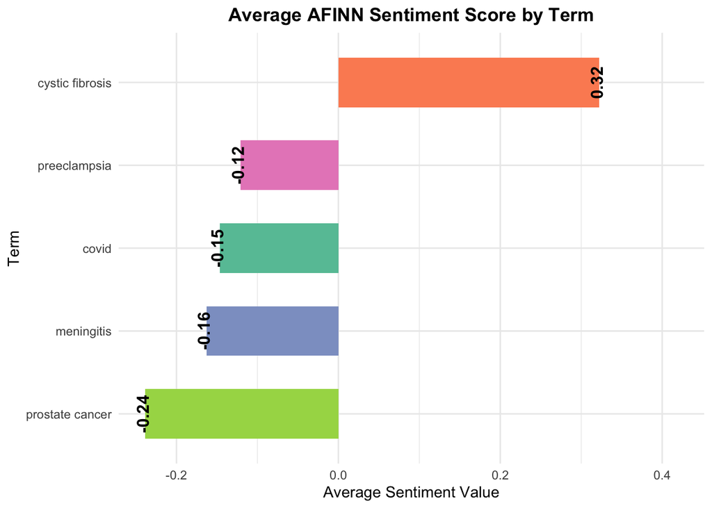

```r
#visualize
ggplot(sentiment_summary,aes(x=reorder(term,mean_sentiment),y=mean_sentiment,fill=term))+
  geom_col(width=0.6,show.legend=FALSE)+
  geom_text(aes(label=round(mean_sentiment, 2)),vjust= 0.3,size=4.2,angle=90,fontface ="bold", color="black")+
  scale_fill_brewer(palette ="Set2")+
  coord_flip()+
  expand_limits(y=max(sentiment_summary$mean_sentiment)*1.3)+
  labs(title="Average AFINN Sentiment Score by Term",x="Term",y="Average Sentiment Value")+
  theme_minimal()+
  theme(
     plot.title = element_text(face = "bold", hjust = 0.5)
  )
```

The term, “cystic fibrosis” is the sole term with a positive sentiment value. This value means that the word has a (slightly) more positive connotation attached to it. Since the scale runs from -5 to 5, this term still does not carry significant positive connotations, just more than the other terms. The object “pubmed_data_afinn” contains all of the average afinn scores for each term in each abstract and the object “sentiment_summary” contains average values of all the afinn values for each term, respectively.